# Part 1

## Part 1 자료다루기

### 1 자료의 종류

#### 자료와 통계학

- 자료 (data) : 하나 이상의 변수 (variable)들에 대한 관측값 (observation)으로 구성됨
- 모집단 (population)
- 표본 (sample)
- 통계학 (statistics)

#### 범주형 (질적) 자료

- 명목형 자료 (nominal data)
- 순서형 자료 (ordinal data)

*이진형 (binary) 또는 이분형 (dichotomous) - 두개의 범주만으로 구성된 범주형 변수*

#### 수치형 (양적) 자료

- 이산형 자료 (discrete data)
- 연속형 자료 (continuous data)

[figure not shown]

#### 자료의 종류의 구분

- 자료의 종류 구분 후 통계분석 방법 결정
- 구분이 모호한 경우

  > 예) 7개 범주의 순서형 자료, 연령

#### 유도된 자료 (derived data)

- 백분율 (percentage) 또는 비율 (proportion)

  > 예) 신약 투여 후 환자의 폐기능(FEV1)이 24% 증가하였다.
- 비 (ratio)

  > 예) 체질량지수(BMI)
- 율 (rate) : 12장, 35장

  > 예) 질병의 율 - 연구대상자들에게 발생하는 전체 질병 건수를 해당 대상자들의 전체 추적조사기간으로 나눈 것, 주로 역학연구에서 사용
- 점수 (score)

*수치형 변수로 간주, 하나 이상의 값들을 사용해 다른 변수를 만드는 경우 각 값들을 모두 기록*

#### 중도절단자료

중도절단(censored) 자료가 얻어지는 경우

- 측정도구의 한계
- 임상시험에서 환자들을 추적 조사하는 경우

### 2 자료입력

#### 자료 입력 형식

- 가로 한 줄은 한 개체에 대한 정보
- 세로 한 줄은 각 변수가 나타나도록 입력
- 엑셀 같은 스프레드시트나 엑세스 혹은 MySQL 같은 데이터베이스 관리 전용 프로그램을 사용한 자료 입력
  - 사용하고자 하는 통계소프트웨어에 맞게 변환 필요
- ASCII 파일이나 텍스트 라일로 저장
  - 각 변수는 빈칸이나 콤마와 같은 구분자 (delimiter)를 이용하여 구분
  - 워드프로세서나 스프레드시트 프로그램을 사용해 자료 입력한 후 ASCII형식으로 저장

#### 자료 입력 계획의 수립

#### 범주형 자료

- 각 범주에 숫자 값을 할당하고 기록지 위에 해당 범주 값 설명 기록
- 단일응답변수 (single-coded variable)
- 다중응답변수 (multi-coded variable)

  > 예) 이 환자가 보인 증상은 무엇입니까?
  > - 응답 가능한 증상들의 총 개수가 적고 환자들이 이 증상들 대부분을 경험하는 경우 : 각 증상 별 문항 만들어 경험 여부 기록
  > - 응답 가능한 증상의 총 개수가 많고 환자들은 단지 이 중 몇 개의 증상만 경험하는 경우 : 환자가 경험한 증상을 명목형 변수로 만듬 환자가 호소한 첫번째 증상은 무엇입니까? 두번째 증상은 무엇입니까?

#### 수치형 자료

- 가능한 한 측정된 값 그대로 기록
- 일관성있는 측정단위 사용

#### 환자 한 사람당 여러 개의 기록지를 사용하는 경우

- 각 자료 내에 환자 id를 부여해 놓고 결합

  > 예제) 유전성 출혈장애를 가진 여성 64명의 ㅛ본으로부터 얻은 자료에 대한 스프레드시트의 일부

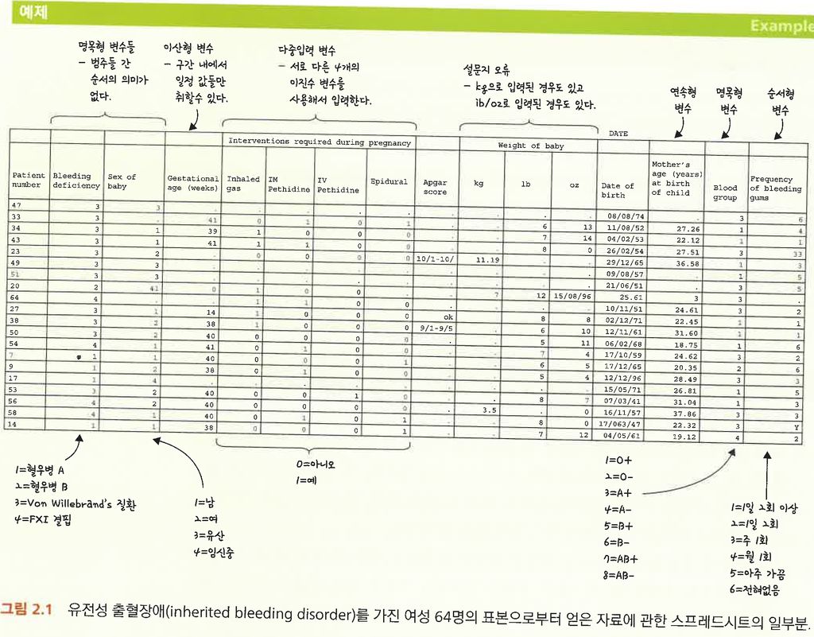

[figure not shown]

#### 날짜와 시간에 관한 문제

- 일관된 입력 형식 사용

  > 예) 일/월/년

#### 결측값 (missing) 입력

- 자료 이력 전 결측값 처리 방식 결정
- 결측값 코딩을 위해 특정 기호 사용

### 3 오류 검토 및 이상값

#### 입력오류 (오타, typing error)

- 이중 입력

#### 오류 검토 (error checking)

- 범주형 자료 (categorical data) : 범주 확인
- 수치형 자료 (numerical data) : 범위 검토
- 날짜 자료 (data) : 연도, 월, 일의 범위 검토 및 환자 나이, 추적기간 등 검토

#### 결측자료 (missing data) 처리

- 결측 가능성은 항상 존재
- 결측비율이 너무 높다면 자료분석결과를 신뢰하기 힘듦
- 특정 변수에 결측값이 유난히 많다면 그 변수를 분석에서 제외 검토
- 어떤 집단 환자에서 특정 변수의 결측이 발생하는 경우 그 집단을 제외하고 분석할 필요 있음
- 완전 무작위 결측 (missing completely at random, MCAR) : 결측값이 완전 무작위로 발생하고 발생원인은 연구변수와 무관
- 무작위 결측 (missing at random, MAR) : 결측값 발생원인이 해당 변수와 무관하나 다른 변수로 설명 가능

  > 예) BMI가 30$\mathrm{kg/m^2}$이상인 연구대상자들에게 다이어트 일지 작성 요구한 경우 다이어트 일지 결측 여부는 연구 대상자들의 BMI에 의해 완전히 결정됨
- 비무작위 결측 (missing not at random, MNAR) : 분석결과가 심하게 편향될 수 있음

  > 환자의 건강상태 자료의 경우 일부 환자들의 건강상태 자료가 결측되었고, 그 이유가 건강이 안 좋아 병원을 방문하지 못했기 때문이라면 이 결측값을 고려하지 않고 분석하면 환자들의 건강상태를 지나치게 낙관적으로 반영한 결과를 얻릉 수 있음

#### 이상값 (outlier)

- 이상값이란 무엇인가?
  - 자료 내 대부분의 값과 매우 다른 극단적인 값
  - 실제 관측값일 수도 있고, 입력 오류일 수도 있음
- 이상값에 대한 검토
  - 범위 검토
  - 그림 이용 : 히스토그램이나 산점도
- 이상값 처리 방법
  - 민감도 분석 (sensitivity anaysis) : 이상값으로 의심되는 값들을 제외하고 분석, 포함하여 분석 $\rightarrow$ 두 부석이 매우 다르면 이상값 존재여부에 크게 영향을 받지 않는 총계분석방법 사용하여 자료분석 (자료 변환, 비모수적 검정)

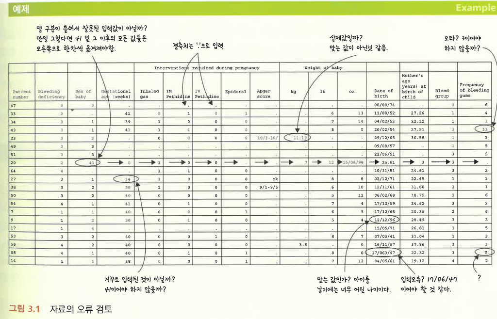

### 4 그림으로 자료 표현하기

쟈료 입력 후 첫번째 해야 할 일 : 그림과 요약통계량을 사용하여 자료를 요약해서 자료에 대한 전반적인 `느낌`을 파악

#### 변수가 하나인

- 빈도분포 (또는 도수분포 frequency distribution) : 범주와 빈도 또는 상대빈도와 함께 제시
- 빈도분포의 표현

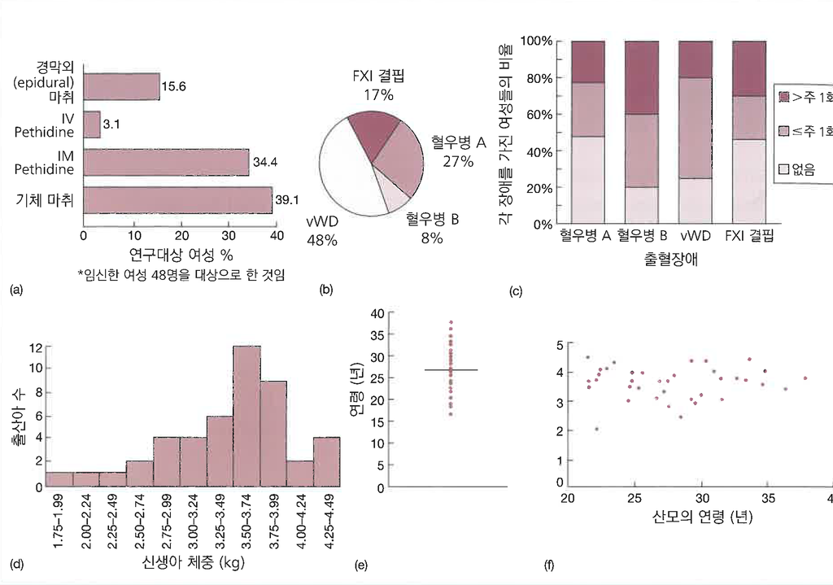

- 빈도분포의 형태
  - 단봉 (unimodal), 이봉 (bimodal), 균일(uniform)
  - 대칭적 (symmetrical)
  - 오른쪽으로 치우침 (skewed to the right) 양의방향으로 치우침 (positively skewed)
  - 왼쪽으로 치우침 (skewed to the left) 음의 방향으로 치우침 (negatively skewed) #### 변수가 두 개인 경우
- 범주형과 수치형 : 각 범주별로 수치형 변수의 히스토그램
- 범주형 두 개 : 집락 막대그림 (clustered bar chart), 구획 막대그림 (segmented var chart)
- 수치형 두개 : 산점도 (scatter diagram) #### 그림을 이용한 이상값 판별

#### 도표 내에서의 연결선 사용

그림 내에서 연결선 사용은 잘못된 내용을 전달할 수 있음으로 주의

> 시간과 용량과 같이 순서의 의미가 있을 때만 사용

### 5 자료의 기술 : 평균적인 값

자료의 위치를 평가하는 일반적인 척도

#### 산술 평균, 평균 (mean)

#### 중앙값 (중위수) (median)

#### 최빈값 (최빈수) (mode)

#### 기하평균 (geometric mean)

> 자료가 오른쪽으로 치우쳐 있는 경우 - 각 자료를 로그 변환하여 자료의 분포를 대칭적으로 바꿀 수 있고, 이 변환 값의 평균은 원 자료값의 기하평균에 해당

#### 가중평균 (weighted mean)

> - 각 자료값의 중요도가 다른 경우 이를 반영 예) 특정 지역 내입원환자들의 평균재원기간을 계산하고자 해당 지역 내 각 병원 별 평균환자 퇴원기간 자료를 얻었다. 만일 병원별 환자 수 정보도 있다면 병원별 환자 수를 가중값으로 사용한 가중평균이용

[figure not shown]

> 예제) 심장질환이 발생한 232명 남자 표본(19장)의 중성지방 값

[figure not shown]

### 6 자료의 기술 : 흩어진 정도

자료의 흩어진 정도를 즉정하는 척도

#### 백분위수 (percentile) 를 사용해 계산되는 범위

- $p\times 100 $ 백분위수 또는 $p$분위수 : 자료를 순서대로 나열할 때 $p\times 100 $% 위치에 있는 자료값
- 십분위수(deciles), 사분위수(quartiles), 중위수(median)
- 백분위수의 사용
  - 사분위 범위 (interquartile range, IQR) : 25백분위수와 75백분위수 차이
  - 십분위범위 (interdecile range) : 10밸분위수와 90백분위수 차이
  - 기준구간 (reference interval), 기준범위 (reference range), 정상범위 (normal range) : 2.5백분위수와 97.5백분위수 차이

#### 표준편차 (standard deviation)

- 분산 (variance) : 산술평균으로부터의 편차 제곱합을 $n-1$으로 나눈 값
- 표준편차 : 분산의 제곱근으로 관찰값의 단위와 동일
- 변동계수 (coefficient of variation, CV) : 평균 대비 자료의 흩어진 정도, 자료의 단위와 부관 #### 개체내 변동 (within-subjects variation)과 개체간 변동 (vetween-subjects variation)
- 개체내 변동 : 반복적으로 측정된 연속형 변수에 대하여 각 개체내에서 반복 측정된 반응값들의 변동
- 개체들 간의 변동

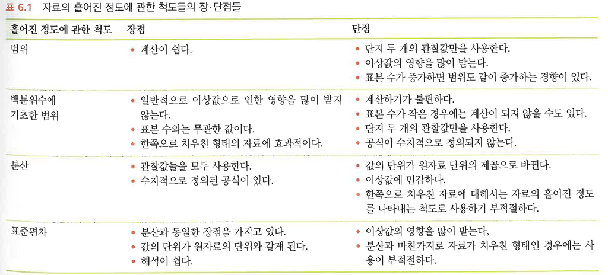

[figure not shown]

### 7 이론적 분포들 : 정규분포

#### 확률 (probability) 의 이해

- 0과 1사이의 값으로 불확실성을 측정
- 통계학이론의 근간
- 여사건 (complementary event)
- 조건부 확률 (conditional probability)
- 주관적 확률
- 빈도주의적 확률
- 사전 확률

#### 확률법칙

- 덧셈법칙
- 곱셈법칙

#### 확률분포 (probability distribution) : 이론

- 확률변수 (random variable)
- 확률분포 (probability distribution)
- 모수 (parameter)
- 통계량 (statistic)
- 이산형 분포
- 연속형분포

#### 정규분포 (normal distribution) : $N(\mu, \sigma^2)$

- 평균 $\mu$, 분산 $\sigma^2$

#### 표준정규분포 (standard normal distribution) $N(0,1)$

- 표준화 $\displaystyle Z=\frac{X-\mu}{\sigma}$

[figure not shown]

### 8 이론적 분포들 : 기타 분포들

분포에 관한 이론보다 상황에 따라 어느 분포를 사용할 것인가 중요

#### (정규분포 외) 연속형 확률분포들

- $t$-분포
- 카이제곱 ($\chi^2$)-분포
- $F$-분포 -로그 정규분포

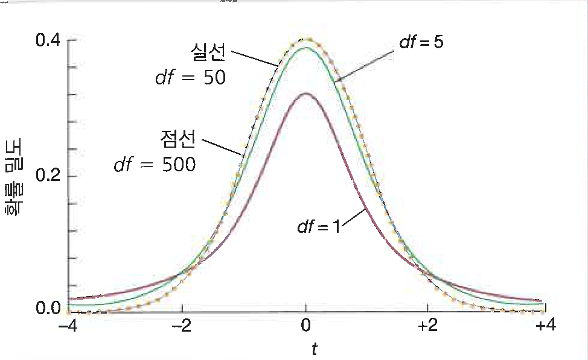

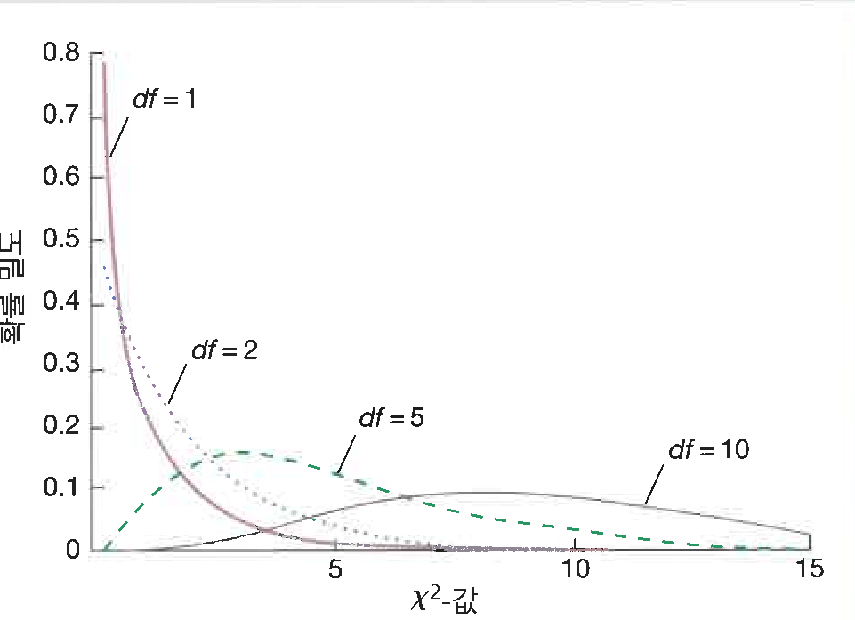

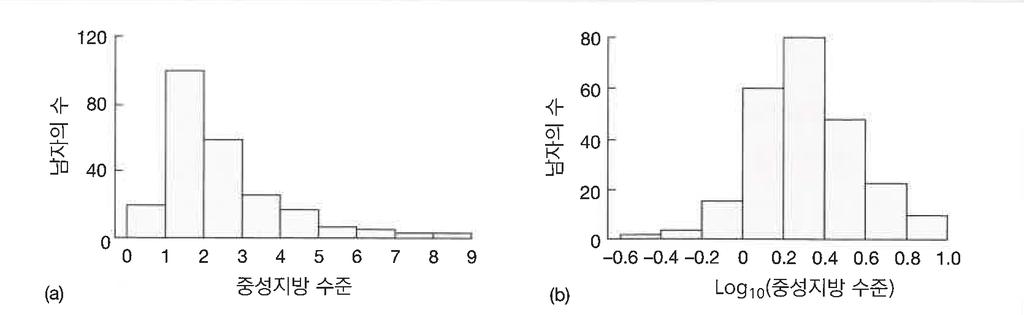

#### 이산형 확률분포들

- 이항분포 (binomial distribution) $B(n,\pi)$

  > 예) $n=100$명의 여성에게 체외수정 후 임신 성공 여부 조사 (각 여성의 임신 확률 $\pi$이 동일하다고 가정)
  > - $n\pi>5, n(1-\pi)>5$인 경우 정규근사 사용
- 포아송 분포 (Poisson distribution) $Poisson(\mu)$

  > 예) 1일 병원입원환자 수

### 9 자료의 변환

#### 왜 변환을 하는가?

- 대부분의 총계분석에서 요구되는 정규분포 가정에 따르지 않는 경우
- 각 집단 별로 흩어진 정도가 다른 경우 (독립표본 $t$-검정이나 분산분석시 필요한 분산동일성 가정 필요)
- 두 변수간의 선형관계가 성립되지 않는 경우 (선형회귀분석시)
- 정규화, 선형화, 분산안정화에 도움  
  #### 자주 사용되는 변환들
- 대수 변환 (로그변환 logarithmic transformation) : $Z=\log Y$
  - 정규화 : $Y$가 오른쪽으로 치우친 경우
  - 선형화 : 변수 $X$와 $Y$가 지수적 관계인 경우
  - 분산안정화 : 큰 $y$에서 큰 분산을 가지는 경우
  - 원자료를 로그변환한 경우 로그 척도 하에서의 군 간 평균 차이는 원래 척도 하에서 군 간 평균의 비 (ratio)와 같음
  - 로그 변환한 결과변수를 이용한 회귀분석을 실시한 경우 회귀계수의 효과는 원래 척도 하에서 가법적 (additive effect)지만, 로그 변환 척도 하에서는 승법적 (multiplicative effect)

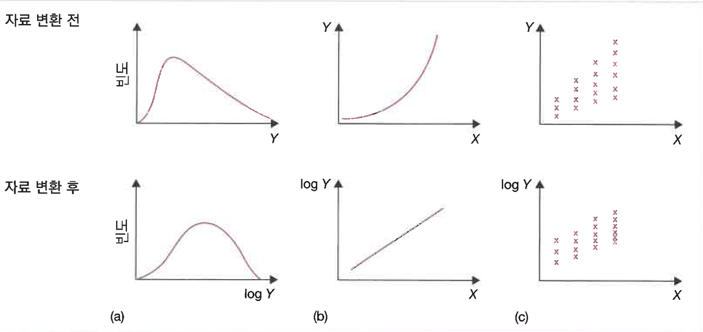

- 제곱근 변환 (square root transformation) $Z=\sqrt{Y}$
  - 로그변환과 비슷한 특성
  - 분산을 평규느로 나눈 값들이 동일한 크기를 다지는 경우 분산 안정화 효과가 있음

    > 예) 포아송변수 : 어떤 시간 또는 공간 영역 내에서 발생하는 희귀사건을 계수한 변수의 경우
- 역수 변환 (reciprocal transformation) $Z=1/Y$
  - 로그변환과 비슷한 특성
  - 분산을 (평균)$^4$로 마뭄 답ㅅ들이 일정한 경우 분산안정화효과가 있음
- 제곱 변환 (square transformation) $Z=Y^2$
  - 정규화 : 자료가 왼쪽으로 치우친 경우
  - 선형화 : 위로 볼록한 관계가 있는 경우
  - 분산안정화 : 변수 값이 증가함에 따라 분산이 감소하는 경우

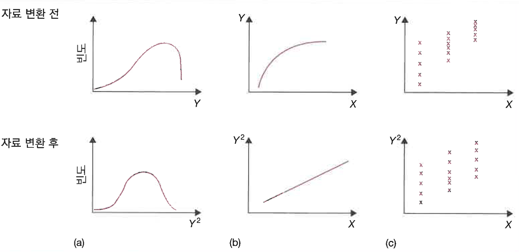

- 로짓 (로지스틱) 변환 (logit (logistic) transformation) $\displaystyle Z=\ln \frac{p}{1-p}$
  - 비율 자료를 다룰 때
  - 0과 1사이의 비율을 $-\infty$와 $\infty$사이의 값으로 변환
  - $S$자형 곡선관계를 선형화

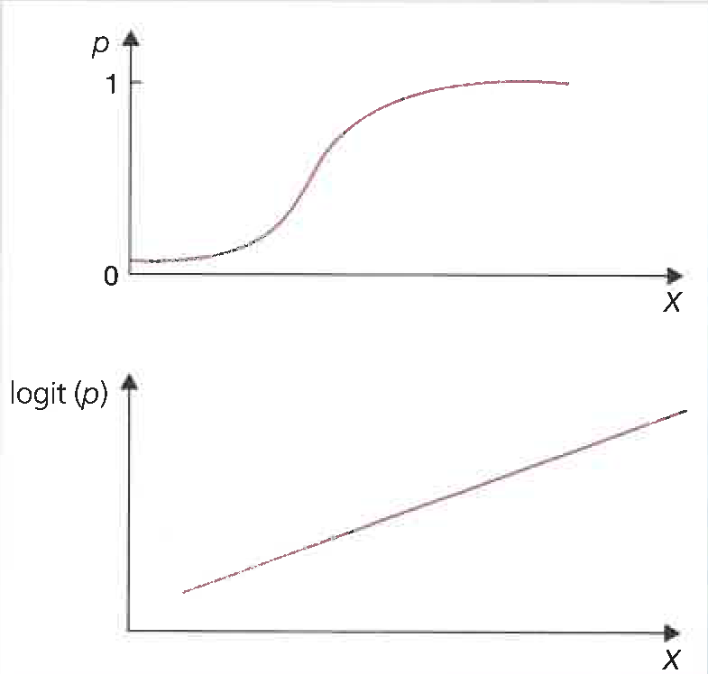

[figure not shown]